# ProyectoTD2022

Grupo K

2022-04-19

## Introducción:

Este proyecto en R está enfocado a analizar los datos recogidos por sensores que monitorizan el nivel de ruido en diferentes localizaciones del barrio de Ruzafa.

### Instalación de paquetes necesarios:

```r
# Especificamos las librerías necesarias en esta lista

packages = c("tidyverse","knitr","ggplot2","readr")

#use this function to check if each package is on the local machine
#if a package is installed, it will be loaded
#if any are not, the missing package(s) will be installed and loaded
package.check <- lapply(packages, FUN = function(x) {
  if (!require(x, character.only = TRUE)) {
    install.packages(x, dependencies = TRUE,repos='http://cran.rediris.es')
  }
  library(x, character.only = TRUE)
})

#verify they are loaded
search()
```

```
##  [1] ".GlobalEnv"        "package:knitr"     "package:forcats"
##  [4] "package:stringr"   "package:dplyr"     "package:purrr"
##  [7] "package:readr"     "package:tidyr"     "package:tibble"
## [10] "package:ggplot2"   "package:tidyverse" "package:stats"
## [13] "package:graphics"  "package:grDevices" "package:utils"
## [16] "package:datasets"  "package:methods"   "Autoloads"
## [19] "package:base"
```

### Numeración de los data frames correspondientes a las estaciones de medida:

1. Datos diarios del sensor de ruido ubicado en el barrio de Ruzafa, en la calle Sueca Esq. Denia
2. Datos diarios del sensor de ruido ubicado en el barrio de Ruzafa, en la calle Cádiz, 16
3. Datos diarios del sensor de ruido ubicado en el barrio de Ruzafa, en la calle Cádiz, 3
4. Datos diarios del sensor de ruido ubicado en el barrio de Ruzafa, en la calle Cuba, 3
5. Datos diarios del sensor de ruido ubicado en el barrio de Ruzafa, en la calle Sueca, 2
6. Datos diarios del sensor de ruido ubicado en el barrio de Ruzafa, en la calle Sueca, 61
7. Datos diarios del sensor de ruido ubicado en el barrio de Ruzafa, en la calle Sueca, 32
8. Datos diarios del sensor de ruido ubicado en el barrio de Ruzafa, en la calle Carles Cervera, Chaflán Reina Doña María
9. Datos diarios del sensor de ruido ubicado en el barrio de Ruzafa, en la calle Salvador Abril Chaflán Maestro José Serrano
10. Datos diarios del sensor de ruido ubicado en el barrio de Ruzafa, en la calle Vivons Chaflán Cádiz
11. Datos diarios del sensor de ruido ubicado en el barrio de Ruzafa, en la calle Carles Cervera, 34
12. Datos diarios del sensor de ruido ubicado en el barrio de Ruzafa, en la calle Puerto Rico, 21
13. Datos diarios del sensor de ruido ubicado en el barrio de Ruzafa, en la calle Doctor Serrano, 21
14. Datos diarios del sensor de ruido ubicado en el barrio de Ruzafa, en la calle General Prim Chaflán Donoso Cortés

```r
# Creamos un vector con los nombres de las estaciones para poder acceder a ellos si es necesario
nombre_estaciones <-
  c("Datos diarios del sensor de ruido ubicado en el barrio de Ruzafa, en la calle Sueca Esq. Denia",
  "Datos diarios del sensor de ruido ubicado en el barrio de Ruzafa, en la calle Cádiz, 16",
  "Datos diarios del sensor de ruido ubicado en el barrio de Ruzafa, en la calle Cádiz, 3",
  " Datos diarios del sensor de ruido ubicado en el barrio de Ruzafa, en la calle Cuba, 3",
  "Datos diarios del sensor de ruido ubicado en el barrio de Ruzafa, en la calle Sueca, 2",
  " Datos diarios del sensor de ruido ubicado en el barrio de Ruzafa, en la calle Sueca, 61",
  " Datos diarios del sensor de ruido ubicado en el barrio de Ruzafa, en la calle Sueca, 32",
  " Datos diarios del sensor de ruido ubicado en el barrio de Ruzafa, en la calle Carles Cervera, Chaflán Reina Doña María",
  " Datos diarios del sensor de ruido ubicado en el barrio de Ruzafa, en la calle Salvador Abril Chaflán Maestro José Serrano",
  " Datos diarios del sensor de ruido ubicado en el barrio de Ruzafa, en la calle Vivons Chaflán Cádiz",
  " Datos diarios del sensor de ruido ubicado en el barrio de Ruzafa, en la calle Carles Cervera, 34",
  " Datos diarios del sensor de ruido ubicado en el barrio de Ruzafa, en la calle Puerto Rico, 21",
  " Datos diarios del sensor de ruido ubicado en el barrio de Ruzafa, en la calle Doctor Serrano, 21",
  " Datos diarios del sensor de ruido ubicado en el barrio de Ruzafa, en la calle General Prim Chaflán Donoso Cortés")
```

## Fase 4

### Importar los datos

```r
# Creamos un vector con los nombres de los ficheros (sin el ".csv")
nombres <- paste0('df',1:14)
nombres
```

```
##  [1] "df1"  "df2"  "df3"  "df4"  "df5"  "df6"  "df7"  "df8"  "df9"  "df10"
## [11] "df11" "df12" "df13" "df14"
```

```r
# Con un bucle for y mediante la funcion assign() le assignamos a cada nombre del
# vector su data frame correspondiente, leido del fichero con la función read_csv
for(x in nombres){
  assign(x,read_csv(str_c("data/",x,".csv"),
                    col_types = cols(dateObserved =
                                       col_datetime(format = "%Y-%m-%d"))))
}

# Si se quisiera comprobar el estado de los data frames tras la importación se
# usaria la funcion head(), que muestra las primeras columnas de un dataframe
# (dado que ocupa mucho espacio en el html/pdf y no aporta gran informacion al
# corrector esta parte esta comentada)
vector_dfs <- list(df1,df2,df3,df4,df5,df6,df7,df8,df9,df10,df11,df12,df13,df14)
# for (x in 1:14){print(head(as.data.frame(vector_dfs[[x]]),n=1))}
```

### Fusionar todos los datos en un solo dataframe

```r
# Creamos un data frame("df") equivalente al df1 con una columna añadida que
# dice de que estación proviene cada registro (en este caso todos provienen de la 1)
df <- df1 %>% mutate(df1,Estacion = 1)

# Con un bucle vamos haciendole joins a df añadiendo toda la informacion del
# resto de data frames, incluyendo en todos la nueva columna que indica en que
# estación se han recogido los datos
for(x in 2:14){
  df <- full_join(df,mutate(vector_dfs[[x]],Estacion = x))
}
```

### Exploración inicial de los datos

Utilizamos funciones como summary, head… Para asi tener una idea de como están distribuidos nuestros datos y de esta forma trabajar de una manera más sencilla.

```r
# La función summary nos da una visualización de las columnas, sus clases y
# otras informaciones
summary(df)
```

```
##       _id            recvTime                   fiwareServicePath
##  Min.   :   1.0   Min.   :2020-09-18 12:40:17   Length:6554
##  1st Qu.: 118.0   1st Qu.:2021-01-18 00:00:29   Class :character
##  Median : 235.0   Median :2021-06-09 00:00:43   Mode  :character
##  Mean   : 395.9   Mean   :2021-07-04 09:52:29
##  3rd Qu.: 775.8   3rd Qu.:2021-12-11 00:00:31
##  Max.   :1008.0   Max.   :2022-04-19 00:01:44
##   entityType          entityId              LAeq           LAeq_d
##  Length:6554        Length:6554        Min.   :49.60   Min.   :51.3
##  Class :character   Class :character   1st Qu.:58.50   1st Qu.:59.6
##  Mode  :character   Mode  :character   Median :60.40   Median :61.7
##                                        Mean   :60.76   Mean   : Inf
##                                        3rd Qu.:62.10   3rd Qu.:63.3
##                                        Max.   :91.30   Max.   : Inf
##     LAeq_den         LAeq_e         LAeq_n       dateObserved
##  Min.   :52.60   Min.   :46.3   Min.   :40.10   Min.   :2020-09-17 00:00:00
##  1st Qu.:61.40   1st Qu.:57.8   1st Qu.:51.40   1st Qu.:2021-01-17 00:00:00
##  Median :63.40   Median :60.1   Median :54.00   Median :2021-06-08 00:00:00
##  Mean   :63.99   Mean   : Inf   Mean   :54.72   Mean   :2021-07-03 09:42:40
##  3rd Qu.:65.80   3rd Qu.:63.2   3rd Qu.:57.50   3rd Qu.:2021-12-10 00:00:00
##  Max.   :96.40   Max.   : Inf   Max.   :90.00   Max.   :2022-04-18 00:00:00
##     Estacion
##  Min.   : 1.000
##  1st Qu.: 4.000
##  Median : 8.000
##  Mean   : 7.595
##  3rd Qu.:11.000
##  Max.   :14.000
```

```r
# La función glimpse de el paquete dplyr nos da una visualización rapida del
# dataframe que estamos tratando.
glimpse(df)
```

```
## Rows: 6,554
## Columns: 12
## $ `_id`             <dbl> 1, 2, 3, 4, 5, 6, 7, 8, 9, 10, 11, 12, 13, 14, 15, 1~
## $ recvTime          <dttm> 2020-11-18 13:40:52, 2020-11-19 00:00:44, 2020-11-2~
## $ fiwareServicePath <chr> "/sonometros", "/sonometros", "/sonometros", "/sonom~
## $ entityType        <chr> "NoiseLevelObserved", "NoiseLevelObserved", "NoiseLe~
## $ entityId          <chr> "T248652-daily", "T248652-daily", "T248652-daily", "~
## $ LAeq              <dbl> 62.4, 58.9, 59.3, 59.4, 58.9, 56.9, 58.2, 58.3, 58.5~
## $ LAeq_d            <dbl> 64.4, 60.5, 60.6, 60.4, 60.2, 58.2, 59.9, 59.8, 59.9~
## $ LAeq_den          <dbl> 63.7, 61.3, 62.5, 62.7, 62.0, 60.8, 60.9, 61.0, 61.5~
## $ LAeq_e            <dbl> 58.7, 59.7, 60.9, 62.4, 60.3, 56.5, 56.6, 58.5, 59.2~
## $ LAeq_n            <dbl> 51.9, 51.3, 53.7, 53.7, 53.1, 53.3, 52.1, 52.0, 52.8~
## $ dateObserved      <dttm> 2020-11-17, 2020-11-18, 2020-11-19, 2020-11-20, 202~
## $ Estacion          <dbl> 1, 1, 1, 1, 1, 1, 1, 1, 1, 1, 1, 1, 1, 1, 1, 1, 1, 1~
```

```r
# Por ultimo la función head nos muestra las primeras filas del df para hacernos
# una idea real
head(as.data.frame(df))
```

```
##   _id            recvTime fiwareServicePath         entityType      entityId
## 1   1 2020-11-18 13:40:52       /sonometros NoiseLevelObserved T248652-daily
## 2   2 2020-11-19 00:00:44       /sonometros NoiseLevelObserved T248652-daily
## 3   3 2020-11-20 00:00:21       /sonometros NoiseLevelObserved T248652-daily
## 4   4 2020-11-21 00:00:22       /sonometros NoiseLevelObserved T248652-daily
## 5   5 2020-11-22 00:02:25       /sonometros NoiseLevelObserved T248652-daily
## 6   6 2020-11-23 00:00:27       /sonometros NoiseLevelObserved T248652-daily
##   LAeq LAeq_d LAeq_den LAeq_e LAeq_n dateObserved Estacion
## 1 62.4   64.4     63.7   58.7   51.9   2020-11-17        1
## 2 58.9   60.5     61.3   59.7   51.3   2020-11-18        1
## 3 59.3   60.6     62.5   60.9   53.7   2020-11-19        1
## 4 59.4   60.4     62.7   62.4   53.7   2020-11-20        1
## 5 58.9   60.2     62.0   60.3   53.1   2020-11-21        1
## 6 56.9   58.2     60.8   56.5   53.3   2020-11-22        1
```

### Preguntas que se puedan responder con los datos disponibles

¿En qué franja horaria el nivel sonoro es más alto? ¿Y el más bajo? ¿En qué sensor el nivel sonoro es más alto? ¿Y el más bajo? ¿En qué día el nivel sonoro fue más alto? ¿Y el más bajo? ¿En qué mes el nivel sonoro es más alto? ¿Y el más bajo?

¿El nivel de ruido depende del día de la semana? ¿El nivel de ruido depende del mes? ¿El nivel de ruido depende de la estación del año? ¿El nivel de ruido depende de la parte del mes en la que estemos (principios, mediados, finales)?

¿Qué franjas horarias tienen los niveles de ruido más parecidos? ¿Qué días de la semana tienen los niveles de ruido más parecidos? ¿Qué meses tienen los niveles de ruido más parecidos?

¿Los niveles de ruido son más altos los fines de semana? ¿Se producen cambios en el nivel de ruido en épocas festivas? ¿En qué medida el nivel de ruido depende del sensor que lo mide?

## Fase 5: Acondicionar los datos para que se correspondan con un tidy dataset

### Eliminar datos innecesarios

```r
# Por las previsualizaciones anteriores podemos darnos cuenta de que hay dos
# columnas que no varian por lo tanto podemos eliminarlas del df
all(df$entityType == "NoiseLevelObserved")
```

```
## [1] TRUE
```

```r
all(df$fiwareServicePath == "/sonometros")
```

```
## [1] TRUE
```

```r
df<- df[,-(3:4)]
```

### Renombrar las variables

```r
# Otra cosa de gran importancia es que los nombres de las columnas deben de ser
# representativos y que se puendan entender. Por ello le vamos a cambiar los
# nombres a unos más simples

colnames(df)
```

```
##  [1] "_id"          "recvTime"     "entityId"     "LAeq"         "LAeq_d"
##  [6] "LAeq_den"     "LAeq_e"       "LAeq_n"       "dateObserved" "Estacion"
```

```r
colnames(df)<- c("id","Fecha_dato","id_sensor","1min","Dia 7-19h",
                 "Dia_tarde_noche", "Tarde 19-23h", "Noche 23-7h",
                 "Dia_medidas", "Estacion")
```

### Representamos las variables en columnas y las observaciones en filas

```r
# De esta forma también nos podemos dar cuenta de que hay unas variables puestas
# como columnas
df <-gather(df, key= Franja_horaria, value= Nivel_sonoro ,4:8)

# Finalmente visualizamos el data frame "df" tidy
head(as.data.frame(df))
```

```
##   id          Fecha_dato     id_sensor Dia_medidas Estacion Franja_horaria
## 1  1 2020-11-18 13:40:52 T248652-daily  2020-11-17        1           1min
## 2  2 2020-11-19 00:00:44 T248652-daily  2020-11-18        1           1min
## 3  3 2020-11-20 00:00:21 T248652-daily  2020-11-19        1           1min
## 4  4 2020-11-21 00:00:22 T248652-daily  2020-11-20        1           1min
## 5  5 2020-11-22 00:02:25 T248652-daily  2020-11-21        1           1min
## 6  6 2020-11-23 00:00:27 T248652-daily  2020-11-22        1           1min
##   Nivel_sonoro
## 1         62.4
## 2         58.9
## 3         59.3
## 4         59.4
## 5         58.9
## 6         56.9
```

## Fase 6

Ajuestes que hay que hacer (no se donde meterlos)

```r
min(df$Nivel_sonoro)
```

```
## [1] 40.1
```

```r
max(df$Nivel_sonoro) # No pueden haber registros con un Nivel sonoro infinito
```

```
## [1] Inf
```

```r
which(df$Nivel_sonoro==Inf) # posicion de los registros con Nivel_sonoro = Inf
```

```
## [1] 10327 20337
```

```r
# Dado que hay dos registros con un Nivel Sonoro con valor de Infinito,
# los replazamos por la media del resto de registros
df$Nivel_sonoro[which(df$Nivel_sonoro==Inf)]<-mean(df$Nivel_sonoro[-which(df$Nivel_sonoro==Inf)])



# Convertimos la estación a factor
df <- df %>% mutate(Estacion =as.factor(Estacion))
```

### Graficos

Nivel sonoro por estación

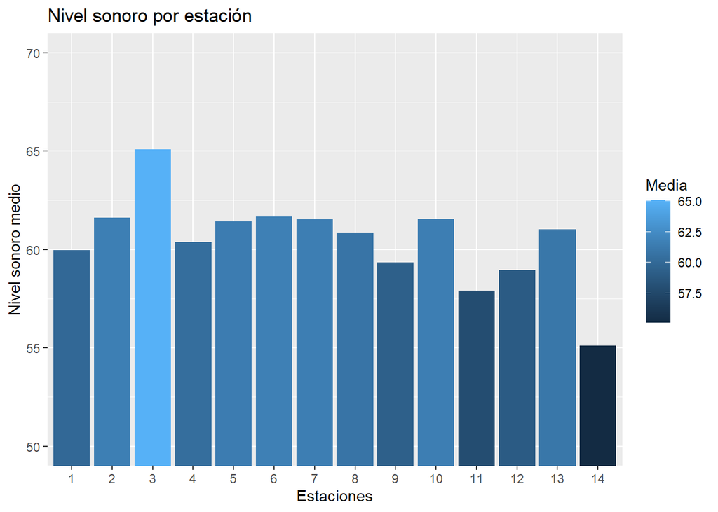

```r
# Seleccionamos la media del nivel sonoro por estación y la estación
df %>% group_by(Estacion) %>%
  mutate(Media = mean(Nivel_sonoro)) %>%
  select(Estacion, Media) %>% unique() %>%

  # Hacemos un grafico de barras con ambas variables, de manera que el color
  # dependa del nivel sonoro medio y añadimos limites al eje x para que se vea
  # mejor la diferencia del nivel sonoro entre estaciones
  ggplot() + geom_col(aes(x= Estacion, y = Media, fill = Media)) +
  coord_cartesian(ylim=c(50, 70)) +

  # Añadimos las etiquetas y leyendas
  labs(x = "Estaciones", y = "Nivel sonoro medio",
       title ="Nivel sonoro por estación")
```

Niveles sonoros máximos y minimos de cada estación

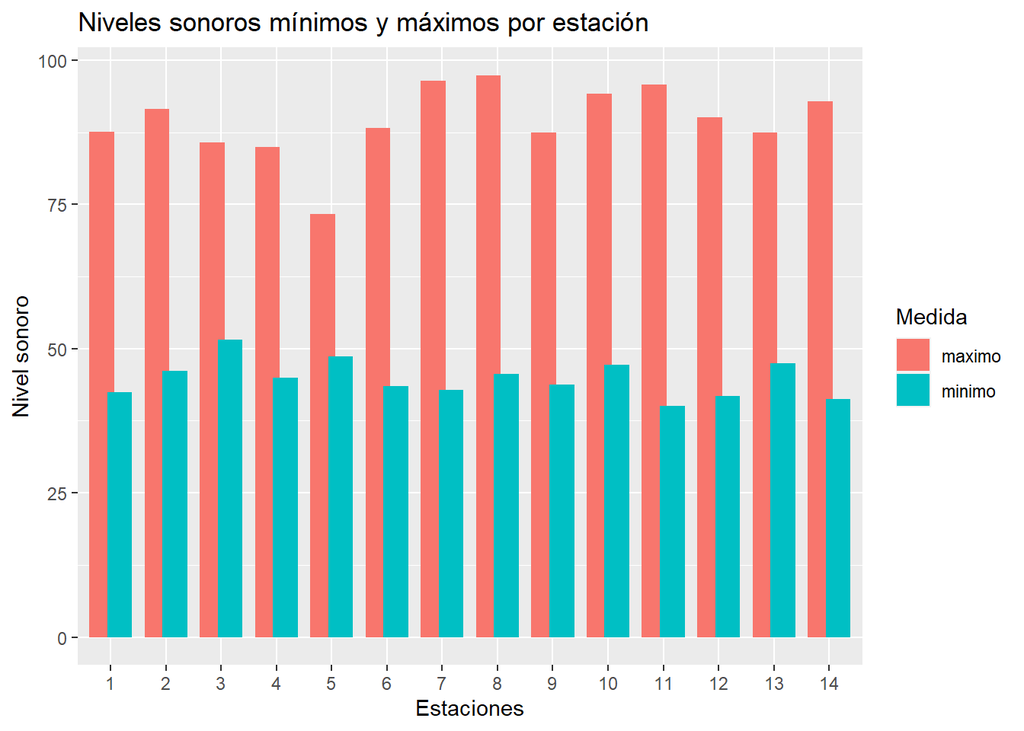

```r
# Seleccionamos los máximos y mínimos de cada estación y la estación
df %>% group_by(Estacion) %>%
  mutate(minimo = min(Nivel_sonoro), maximo = max(Nivel_sonoro)) %>%
  select(Estacion, maximo, minimo) %>%
  unique() %>%
  gather(key = Medida, value =Valor,-Estacion) %>% # Al crear las variables
                                                   # minimo y maximo hay que
                                                   # volver a hacer tidy el
                                                   # data frame

  # Hacemos un grafico de barras con las variables Estacion, Valor y Medida y
  # agrupando visualmente por estaciones con el argumento position
  ggplot() +
  geom_col(aes(x = Estacion,y=Valor, fill=Medida), position = position_dodge(width = 0.65)) +

  #Añadimos las etiquetas y leyendas
  labs(x = "Estaciones", y = "Nivel sonoro",
       title ="Niveles sonoros mínimos y máximos por estación")
```